# Multilevel Model Estimation Using the Lueven Clinical Data Set

Author

Ginette Lafit

Published

June 8, 2023

## Settings things up

Before we proceed, we need to ensure we have several packages installed and loaded into our `R` session. For the scripts below, we will use the following packages:

- [`tidyverse`](https://CRAN.R-project.org/package=tidyverse)
- [`data.table`](https://CRAN.R-project.org/package=data.table)
- [`psych`](https://CRAN.R-project.org/package=psych)
- [`viridis`](https://CRAN.R-project.org/package=viridis)
- [`devtools`](https://CRAN.R-project.org/package=devtools)
- [`nlme`](https://CRAN.R-project.org/package=nlme)

Which we can install in one go as follows:

```r
# Prepare the package list.
packages = c(
    "tidyverse", "data.table", "psych",
    "viridis", "devtools", "nlme"
)

# Install packages.
install.packages(packages)
```

**Tip**

Now that we have all packages installed, we continue by loading them.

```r
# Handy collection of packages for data manipulation and plotting.
library(tidyverse)

# To create lagged outcome.
library(data.table)

# To compute descriptive statistics.
library(psych)

# Color scales adapted for colorblindness.
library(viridis)

# To estimate mixed-effects models.
library(nlme)
```

Additionally, we may also need to install and load the `PowerLAPIM` package from `GitHub`:

```r
# Install
devtools::install_github("ginettelafit/PowerLAPIM", force = TRUE)
```

To complete the setup, we also need to set the seed for reproducibility.

```r
# Set a seed for reproducibility.
set.seed(123)
```

## Description

In this tutorial, we use data from Heininga et al. (2019). In this study, the authors applied the ESM methodology to study emotion dynamics in people with *Major Depressive Disorder* (MDD). The study consist of an ESM testing period of seven days in which participants had to fill out questions about mood and social context on their daily lives ten times a day (i.e., $70$ measurement occasions). The data set contains $38$ participants diagnosed with MDD and $40$ control subjects. Participants filled out the ESM questionnaires in a stratified random interval scheme between 9:30 AM and 9:30 PM.

The data set contains the following variables:

- `PID` that denotes the individual identification number
- `day` is a variable that ranges from 1 to 7 and identifies the day of ESM testing
- `daybeep` is a variable that ranges from 1 to 10 and identifies the number of the prompt or beep within a day
- `PA` is the *positive affect* computed as the mean of items:
  - *How happy do you feel at the moment?*
  - *How relaxed do you feel at the moment?*
  - *How euphoric do you feel at the moment?*
- `NA.` is the *negative affect* computed as the mean of items:
  - *How depressed do you feel at the moment?*
  - *How stressed do you feel at the moment?*
  - *How anxious do you feel at the moment?*
  - *How angry do you feel at the moment?*
  - *How restless do you feel at the moment?*
- `anhedonia` corresponds to the ESM item:
  - *To what degree do you find it difficult to experience pleasure in activities at the moment?*
- `MDD` is a dummy variable equal to one when the individual has been diagnosed with MDD and 0 otherwise
- `QIDS` denotes the sum of the items of the *Quick Inventory of Depressive Symptomatology* (QIDS; Rush et al., 2003). QIDS was measured before the ESM testing period.

First, we are going to load the data set:

```r
# Load the data set.
load(file = "assets/data/clinical-dataset.RData")
```

**Tip**

Make sure you load the data from the location where you downloaded it. If your analysis script (i.e., the `.R` file) and the dataset are in the same location, than you can simply load the data as follows:

```r
load(file = "clinical-dataset.RData")
```

## Data exploration

In this section we will explore briefly the variables in the data set.

### Data structure

Now, that we have the data ready, we can start by exploring it to get a better understanding of the variable measured.

```r
# Find the dimensions.
dim(data)
```

```
[1] 5460    8
```

```r
# Find the structure.
str(data)
```

```
'data.frame':   5460 obs. of  8 variables:
 $ PID      : num  101 101 101 101 101 101 101 101 101 101 ...
 $ day      : num  1 1 1 1 1 1 1 1 1 1 ...
 $ daybeep  : num  1 2 3 4 5 6 7 8 9 10 ...
 $ PA       : num  NA 27.3 49.7 43 43 ...
 $ NA.      : num  NA 30.4 23.8 24.2 32.8 19.6 18.4 21.2 23 21.8 ...
 $ anhedonia: num  NA 26 25 25 50 21 42 30 22 30 ...
 $ MDD      : num  1 1 1 1 1 1 1 1 1 1 ...
 $ QIDS     : num  12 12 12 12 12 12 12 12 12 12 ...
```

```r
# See the first 6 rows.
head(data)
```

```
  PID day daybeep       PA  NA. anhedonia MDD QIDS
1 101   1       1       NA   NA        NA   1   12
2 101   1       2 27.33333 30.4        26   1   12
3 101   1       3 49.66667 23.8        25   1   12
4 101   1       4 43.00000 24.2        25   1   12
5 101   1       5 43.00000 32.8        50   1   12
6 101   1       6 18.00000 19.6        21   1   12
```

```r
# See the last 6 rows.
tail(data)
```

```
     PID day daybeep       PA  NA. anhedonia MDD QIDS
5455 645   7       5 70.66667  9.4        10   0    4
5456 645   7       6 73.66667 11.0        20   0    4
5457 645   7       7 64.33333 10.8        18   0    4
5458 645   7       8 69.66667 11.2        10   0    4
5459 645   7       9 73.33333 13.0        18   0    4
5460 645   7      10 65.66667 15.2        15   0    4
```

```r
# Find the column names.
names(data)
```

```
[1] "PID"       "day"       "daybeep"   "PA"        "NA."       "anhedonia"
[7] "MDD"       "QIDS"
```

```r
# Summary of the data.
summary(data)
```

```
      PID             day       daybeep           PA             NA.
 Min.   :101.0   Min.   :1   Min.   : 1.0   Min.   : 0.00   Min.   :  0.00
 1st Qu.:131.0   1st Qu.:2   1st Qu.: 3.0   1st Qu.:23.00   1st Qu.:  6.60
 Median :601.5   Median :4   Median : 5.5   Median :36.33   Median : 18.80
 Mean   :390.2   Mean   :4   Mean   : 5.5   Mean   :37.07   Mean   : 25.61
 3rd Qu.:624.0   3rd Qu.:6   3rd Qu.: 8.0   3rd Qu.:50.00   3rd Qu.: 40.30
 Max.   :645.0   Max.   :7   Max.   :10.0   Max.   :93.67   Max.   :100.00
                                            NA's   :629     NA's   :629
   anhedonia           MDD              QIDS
 Min.   :  0.00   Min.   :0.0000   Min.   : 0.000
 1st Qu.:  7.00   1st Qu.:0.0000   1st Qu.: 3.000
 Median : 28.00   Median :0.0000   Median : 8.000
 Mean   : 33.34   Mean   :0.4872   Mean   : 9.359
 3rd Qu.: 56.00   3rd Qu.:1.0000   3rd Qu.:16.000
 Max.   :100.00   Max.   :1.0000   Max.   :24.000
 NA's   :629
```

```r
# Number of participants.
length(unique(data$PID))
```

```
[1] 78
```

```r
# Create variable to store the number of observations per person.
data$obs = rep(0, nrow(data))

# Count the number of observation per person.
for (i in unique(data$PID)) {
    data$obs[which(data$PID == i)] <- 1:length(which(data$PID == i))
}

# Show the number of observations per person.
table(data$obs)
```

```
 1  2  3  4  5  6  7  8  9 10 11 12 13 14 15 16 17 18 19 20 21 22 23 24 25 26
78 78 78 78 78 78 78 78 78 78 78 78 78 78 78 78 78 78 78 78 78 78 78 78 78 78
27 28 29 30 31 32 33 34 35 36 37 38 39 40 41 42 43 44 45 46 47 48 49 50 51 52
78 78 78 78 78 78 78 78 78 78 78 78 78 78 78 78 78 78 78 78 78 78 78 78 78 78
53 54 55 56 57 58 59 60 61 62 63 64 65 66 67 68 69 70
78 78 78 78 78 78 78 78 78 78 78 78 78 78 78 78 78 78
```

### Descriptive statistics and visualizations

We first compute descriptive statistics including number of participant, number of observations per day, and compliance.

```r
# Get number of participants.
length(unique(data$PID))
```

```
[1] 78
```

```r
# Obtain number of participants diagnosed with `MDD`.
length(unique(data$PID[data$MDD == 1]))
```

```
[1] 38
```

```r
# Obtain number of participants in the control group.
length(unique(data$PID[data$MDD == 0]))
```

```
[1] 40
```

```r
# Get the number of assessment per day.
table(data$PID)
```

```
101 102 103 105 108 109 110 111 112 114 115 117 119 120 121 124 125 128 130 131
 70  70  70  70  70  70  70  70  70  70  70  70  70  70  70  70  70  70  70  70
132 135 136 138 139 140 141 143 144 202 204 205 206 207 208 210 211 306 601 602
 70  70  70  70  70  70  70  70  70  70  70  70  70  70  70  70  70  70  70  70
603 604 606 607 608 609 610 611 612 613 614 615 616 618 619 621 622 623 624 625
 70  70  70  70  70  70  70  70  70  70  70  70  70  70  70  70  70  70  70  70
626 627 628 629 630 631 632 634 635 636 637 638 640 641 642 643 644 645
 70  70  70  70  70  70  70  70  70  70  70  70  70  70  70  70  70  70
```

```r
# Get the number of assessment per day for each participant.
beeps.person <- lapply(
    data$PID, function(i) {
        table(data$day[which(data$PID == i)])
    }
)

# Show results for some of the participants.
beeps.person[1:6]
```

```
[[1]]

 1  2  3  4  5  6  7
10 10 10 10 10 10 10

[[2]]

 1  2  3  4  5  6  7
10 10 10 10 10 10 10

[[3]]

 1  2  3  4  5  6  7
10 10 10 10 10 10 10

[[4]]

 1  2  3  4  5  6  7
10 10 10 10 10 10 10

[[5]]

 1  2  3  4  5  6  7
10 10 10 10 10 10 10

[[6]]

 1  2  3  4  5  6  7
10 10 10 10 10 10 10
```

```r
# Compute a binary variable indicating if a participant answered a beep. We take
# the ESM item PA as reference because in this ESM design participants were not
# allowed to skip items.
data$Compliance <- ifelse(is.na(data$PA) == FALSE, 1, 0)

# Mean, median of the compliance across all participants.
describe(data$Compliance)
```

```
   vars    n mean   sd median trimmed mad min max range  skew kurtosis se
X1    1 5460 0.88 0.32      1    0.98   0   0   1     1 -2.41     3.81  0
```

```r
# Compliance per participant.
data.compliance.person <- aggregate(
    data$Compliance,
    by = list(data$PID),
    mean,
    na.rm = TRUE
)

# See the first 6 rows.
head(data.compliance.person)
```

```
  Group.1         x
1     101 0.9142857
2     102 0.8857143
3     103 0.9571429
4     105 0.9714286
5     108 0.6000000
6     109 0.9857143
```

```r
# See the last 6 rows.
tail(data.compliance.person)
```

```
   Group.1         x
73     640 0.7714286
74     641 0.8571429
75     642 0.9428571
76     643 0.9857143
77     644 0.7142857
78     645 0.9571429
```

```r
# Obtain descriptive statistics of person's average compliance.
describe(data.compliance.person$x)
```

```
   vars  n mean  sd median trimmed  mad  min max range  skew kurtosis   se
X1    1 78 0.88 0.1   0.92     0.9 0.07 0.54   1  0.46 -1.29     1.28 0.01
```

Next, we obtain descriptive statistics of the distribution of the person-level or time-invariant variables.

```r
# We create a variable including the
# diagnosis (i.e. 1 = `MDD` and 0 = control group),
# and depression (`QIDS`) for each participant.
dt.person <- aggregate(
    cbind(data$MDD, data$QIDS),
    by = list(data$PID),
    mean,
    na.rm = TRUE
)

# Add column names.
colnames(dt.person) <- c("Group.1", "MDD", "QIDS")

# See the first 6 rows.
head(dt.person)
```

```
  Group.1 MDD QIDS
1     101   1   12
2     102   1   10
3     103   1   18
4     105   1   16
5     108   1    5
6     109   1   14
```

```r
# See the last 6 rows.
tail(dt.person)
```

```
   Group.1 MDD QIDS
73     640   0    1
74     641   0    4
75     642   0    0
76     643   0    6
77     644   0   10
78     645   0    4
```

```r
# Descriptive statistics for time-invariant variable `QIDS`.
describe(dt.person$QIDS)
```

```
   vars  n mean   sd median trimmed mad min max range skew kurtosis   se
X1    1 78 9.36 7.35      8    8.92 8.9   0  24    24 0.43    -1.25 0.83
```

```r
# Descriptive statistics for time-invariant variable `QIDS` for `MDD = 1`.
describe(dt.person$QIDS[dt.person$MDD == 1])
```

```
   vars  n  mean sd median trimmed  mad min max range skew kurtosis   se
X1    1 38 15.71  5     16   15.88 5.93   5  24    19 -0.3    -0.82 0.81
```

```r
# Descriptive statistics for time-invariant variable `QIDS` for `MDD = 0`.
describe(dt.person$QIDS[dt.person$MDD == 0])
```

```
   vars  n mean   sd median trimmed  mad min max range skew kurtosis  se
X1    1 40 3.33 2.53      3    3.03 1.48   0  10    10 0.94     0.54 0.4
```

We now focus the time-varying variables, we obtain visualization and descriptive statistics for the time-varying variable negative affect (NA).

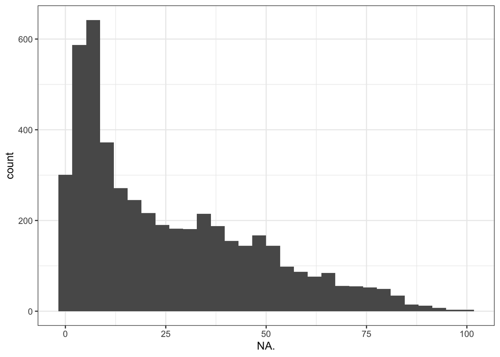

```r
# Histogram for the time-varying variable negative affect (i.e.  `NA.`).
ggplot(data, aes(NA.)) +
    geom_histogram(
        bins = 30
    ) +
    scale_fill_viridis() +
    theme_bw()
```

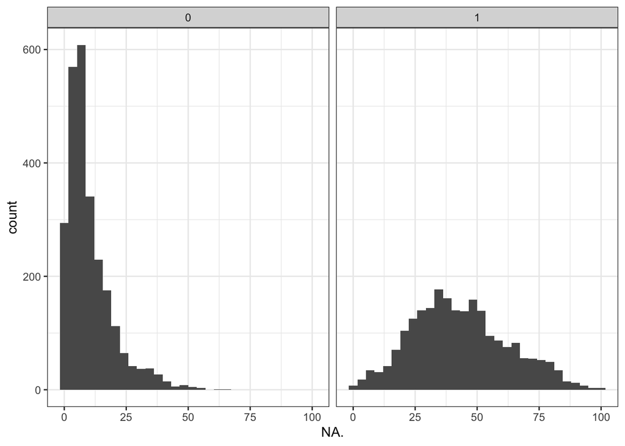

```r
# Histogram for the time-varying variable `NA.` by `MDD`.
ggplot(data, aes(NA.)) +
    geom_histogram(
        bins = 30
    ) +
    facet_wrap(
        . ~ MDD
    ) +
    scale_fill_viridis() +
    theme_bw()
```

```r
# Descriptive statistics for `NA.`.
describe(data$NA.)
```

```
   vars    n  mean    sd median trimmed   mad min max range skew kurtosis   se
X1    1 4831 25.61 22.19   18.8   22.95 21.05   0 100   100 0.86    -0.17 0.32
```

```r
# Descriptive statistics for `NA.` in the `MDD` group.
describe(data$NA.[data$MDD == 1])
```

```
   vars    n  mean    sd median trimmed   mad min max range skew kurtosis  se
X1    1 2255 43.28 19.22   41.2   42.57 19.57   0 100   100 0.31    -0.39 0.4
```

```r
# Descriptive statistics for `NA.` in the control group.
describe(data$NA.[data$MDD == 0])
```

```
   vars    n  mean   sd median trimmed  mad min max range skew kurtosis   se
X1    1 2576 10.15 9.34    7.2    8.68 6.23   0  66    66 1.75     3.77 0.18
```

```r
# Distribution of happy per participant.
data.table.dt <- setDT(na.omit(data))
data.table.dt[, as.list(summary(NA., na.omit = TRUE)), by = PID]
```

```
    PID Min. 1st Qu. Median      Mean 3rd Qu.  Max.
 1: 101 14.4   21.40   25.9 29.621875   36.25  65.6
 2: 102 14.4   32.40   38.2 39.090323   46.25  64.2
 3: 103 25.4   57.50   66.6 65.528358   75.10  93.2
 4: 105 25.2   42.80   50.7 50.235294   57.40  77.8
 5: 108  9.0   13.40   17.1 17.647619   21.35  37.6
 6: 109 11.6   25.80   32.2 33.956522   43.20  60.8
 7: 110  7.8   20.60   29.4 31.664615   40.60  68.6
 8: 111 13.2   24.40   26.3 26.767647   30.05  45.6
 9: 112 47.4   62.50   66.2 68.817910   73.90  92.2
10: 114  5.6   27.85   35.3 36.342424   44.45  73.8
11: 115 18.0   42.40   56.2 57.168627   77.80  84.2
12: 117 22.2   27.80   35.4 34.553125   40.05  51.4
13: 119 12.8   26.80   38.6 37.927869   46.00  91.0
14: 120 24.4   35.30   40.4 40.857576   46.60  54.6
```

[output cut: 65 more lines]

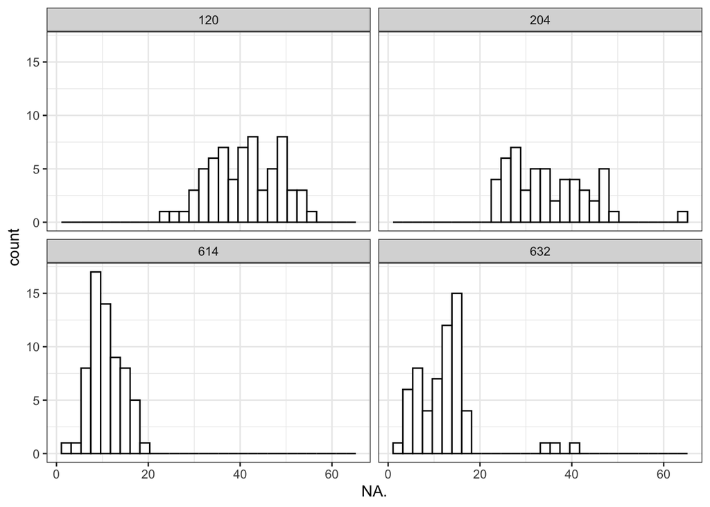

```r
# We randomly select 10 participants for plotting the
# distribution of the time-varying variable `NA.`.
n.ID.sample <- sample(unique(data$PID), 4)
data.person.sample <- data[which(data$PID %in% n.ID.sample), ]

# Histogram for the time-varying variable happy by person
ggplot(data.person.sample, aes(NA.)) +
    geom_histogram(color = "black", fill = "white", bins = 30) +
    facet_wrap(~PID) +
    scale_fill_viridis() +
    theme_bw()
```

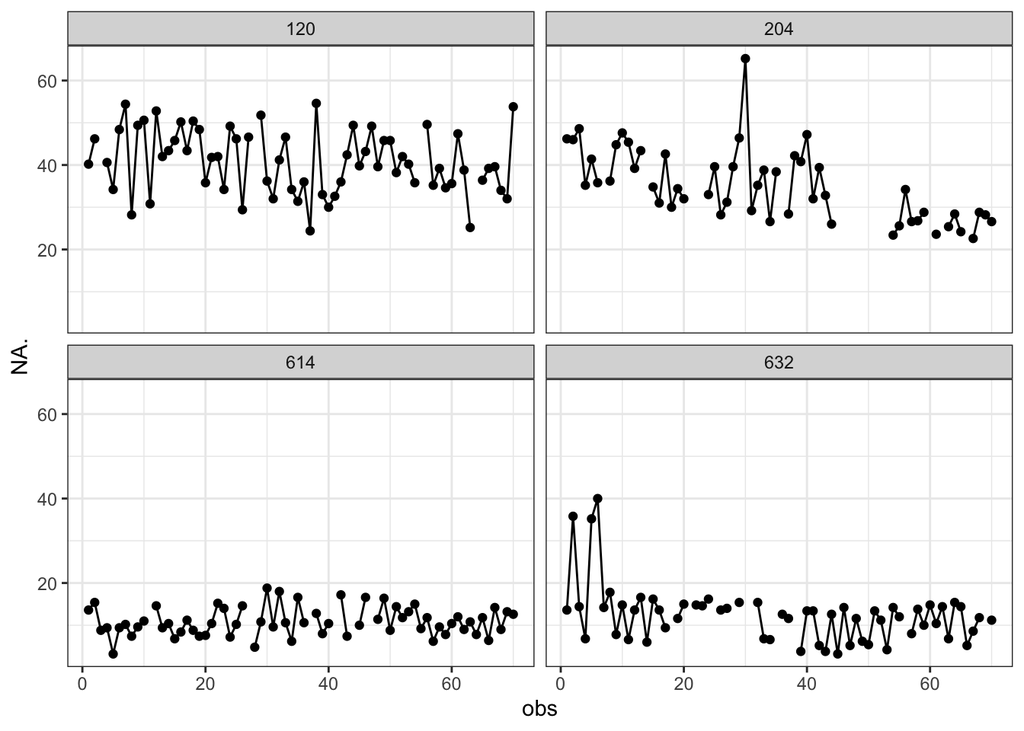

```r
# Plot the trajectories of the time-varying variable NA by person
data.person.sample %>%
    ggplot(aes(x = obs, y = NA.)) +
    geom_point() +
    geom_line() + # add lines to connect the data for each person
    facet_wrap(. ~ PID) +
    scale_fill_viridis() +
    theme_bw()
```

```r
# We create a variable including the `MDD` (1 = `MDD`, 0 = control group),
# and person's means of the time-varying variable `NA.`.
dt.person <- aggregate(
    cbind(data$MDD, data$NA.),
    by = list(data$PID),
    mean,
    na.rm = TRUE
)

# Add column names.
colnames(dt.person) <- c("Group.1", "MDD", "NA.")

# See the first 6 rows.
head(dt.person)
```

```
  Group.1 MDD      NA.
1     101   1 29.62187
2     102   1 39.09032
3     103   1 65.52836
4     105   1 50.23529
5     108   1 17.64762
6     109   1 33.95652
```

```r
# See the last 6 rows.
tail(dt.person)
```

```
   Group.1 MDD       NA.
73     640   0  8.114815
74     641   0  9.723333
75     642   0  5.451515
76     643   0 12.075362
77     644   0 20.696000
78     645   0 17.811940
```

```r
# Descriptive statistics for person's means of the time-varying variable `NA.`.
describe(dt.person$NA.)
```

```
   vars  n  mean    sd median trimmed   mad  min   max range skew kurtosis   se
X1    1 78 26.24 19.91  20.69   24.23 21.06 1.37 81.21 79.84 0.72    -0.45 2.25
```

```r
# Descriptive statistics for person's means of the time-varying variable `NA.`
# for `MDD` = 1.
describe(dt.person$NA.[dt.person$MDD == 1])
```

```
   vars  n  mean    sd median trimmed   mad   min   max range skew kurtosis
X1    1 38 42.96 15.02  40.23   42.29 14.06 13.53 81.21 67.68 0.51    -0.06
     se
X1 2.44
```

```r
# Descriptive statistics for person's means of the time-varying variable `NA.`
# for `MDD` = 0.
describe(dt.person$NA.[dt.person$MDD == 0])
```

```
   vars  n  mean   sd median trimmed  mad  min   max range skew kurtosis   se
X1    1 40 10.36 6.14   9.21     9.5 4.76 1.37 29.71 28.35 1.27     1.32 0.97
```

```r
# We create a variable including the `MDD` (1 = `MDD`, 0 = control group),
# and person's standard deviation of the time-varying variable `NA.`.
dt.person.sd <- aggregate(
    data$NA.,
    by = list(data$PID, data$MDD),
    sd,
    na.rm = TRUE
)

# Add column names.
colnames(dt.person.sd) <- c("Group.1", "MDD", "NA.")

# See the first 6 rows.
head(dt.person.sd)
```

```
  Group.1 MDD       NA.
1     601   0 10.139970
2     602   0  2.905915
3     603   0 12.948615
4     604   0  6.165745
5     606   0  3.925499
6     607   0 12.595571
```

```r
# See the last 6 rows.
tail(dt.person.sd)
```

```
   Group.1 MDD       NA.
73     206   1 10.115789
74     207   1 12.116928
75     208   1 12.489439
76     210   1 17.420019
77     211   1  6.747881
78     306   1 14.098726
```

```r
# Descriptive statistics for person's standard deviation of the time-varying
# variable `NA.`.
describe(dt.person.sd$NA.)
```

```
   vars  n mean   sd median trimmed  mad  min   max range skew kurtosis   se
X1    1 78 8.97 4.67   8.67    8.56 5.22 2.14 27.32 25.18 1.06     1.81 0.53
```

```r
# Descriptive statistics for person's standard deviation of the time-varying
# variable `NA.` for `MDD` = 1.
describe(dt.person.sd$NA.[dt.person.sd$MDD == 1])
```

```
   vars  n  mean  sd median trimmed  mad  min   max range skew kurtosis   se
X1    1 38 11.44 4.7  10.98      11 3.59 4.16 27.32 23.16  1.1     1.76 0.76
```

```r
# Descriptive statistics for person's standard deviation of the time-varying
# variable `NA.` for `MDD` = 0.
describe(dt.person.sd$NA.[dt.person.sd$MDD == 0])
```

```
   vars  n mean   sd median trimmed  mad  min   max range skew kurtosis   se
X1    1 40 6.63 3.24   5.62    6.35 3.29 2.14 12.95  10.8 0.62    -0.89 0.51
```

## Example 1

*Estimating the effect of a continuous time-varying predictor*

The first illustrative example shows how to estimate the effect of a time-varying predictor on the outcome of interest. Considering the Leuven clinical study, we are interested in studying the impact of *anhedonia* on *negative affect* in daily life on patients with *major depressive disorder*.

We use the data of $38$ individuals diagnosed with MDD. We select the individuals diagnosed with MDD.

```r
# Create `MDD` subset.
data.MDD <- data[which(data$MDD == 1), ]
```

First, we are going to estimate the individual means, the mean across all participants, and the standard deviation of the variable `anhedonia`.

```r
# Compute the group mean of anhedonia.
groupmean_X = aggregate(
    data.MDD$anhedonia,
    list(data.MDD$PID),
    FUN = mean,
    data = data.MDD,
    na.rm = TRUE
)

# Compute the mean.
mean_X <- mean(groupmean_X[, 2])

# Print the mean.
print(mean_X)
```

```
[1] 51.66162
```

```r
# Compute the standard deviation.
sd_X <- sd(data.MDD$anhedonia, na.rm = TRUE)

# Print the standard deviation.
print(sd_X)
```

```
[1] 23.6734
```

Next, we are going to person mean-centered the variable `anhedonia`.

```r
# Centered within individuals anhedonia.
N.i <- unique(data.MDD$PID)
anhedonia.c = rep(0, nrow(data.MDD))

for (i in N.i) {
    # Get the anhedonia for the i-th individual.
    ith_anhedonia <- data.MDD$anhedonia[which(data.MDD$PID == i)]

    # Get the mean of anhedonia for the i-th individual.
    ith_anhedonia_mean <- mean(data.MDD$anhedonia[which(data.MDD$PID == i)], na.rm = TRUE)

    # Center.
    anhedonia.c[which(data.MDD$PID == i)] <- ith_anhedonia - ith_anhedonia_mean
}

# Add the centered variable to the data.
data.MDD <- cbind(data.MDD, anhedonia.c)
```

We estimate the linear mixed-effects model assuming $\text{AR}(1)$ errors:

```r
# Fit a linear mixed-effects model to data.
fit.Model.1 = lme(
    fixed = NA. ~ 1 + anhedonia.c,
    random = ~ 1 + anhedonia.c | PID,
    na.action = na.omit,
    data = data.MDD,
    correlation = corAR1(),
    method = "REML"
)
```

The summary of the estimation results is given by:

```r
# Summary of the estimation results.
summary(fit.Model.1)
```

```
Linear mixed-effects model fit by REML
  Data: data.MDD
       AIC      BIC    logLik
  17319.52 17359.56 -8652.758

Random effects:
 Formula: ~1 + anhedonia.c | PID
 Structure: General positive-definite, Log-Cholesky parametrization
            StdDev     Corr
(Intercept) 14.7788373 (Intr)
anhedonia.c  0.1162717 0.003
Residual    11.9150994

Correlation Structure: AR(1)
 Formula: ~1 | PID
 Parameter estimate(s):
      Phi
0.4293834
Fixed effects:  NA. ~ 1 + anhedonia.c
               Value Std.Error   DF   t-value p-value
(Intercept) 42.98279 2.4299657 2216 17.688641       0
anhedonia.c  0.13900 0.0233386 2216  5.955752       0
 Correlation:
            (Intr)
anhedonia.c 0.002

Standardized Within-Group Residuals:
        Min          Q1         Med          Q3         Max
-4.21865272 -0.56951096 -0.04394045  0.53168368  6.16917066

Number of Observations: 2255
Number of Groups: 38
```

Obtain confidence intervals:

```r
# Confidence intervals.
intervals(fit.Model.1, which = "fixed")
```

```
Approximate 95% confidence intervals

 Fixed effects:
                  lower       est.      upper
(Intercept) 38.21754213 42.9827900 47.7480379
anhedonia.c  0.09323107  0.1389989  0.1847667
```

The estimated fixed intercept is given by:

```r
# Extract fixed effect coefficients.
# Extract the value of fixed intercept.
coef(summary(fit.Model.1))[1, 1]
```

```
[1] 42.98279
```

```r
# Extract the value of the fixed slope.
coef(summary(fit.Model.1))[2, 1]
```

```
[1] 0.1389989
```

The standard deviation and autocorrelation of the level 1 residuals are extracted as follows:

```r
# Extract level 1 residuals standard deviation.
as.numeric(VarCorr(fit.Model.1)[3, 2])
```

```
[1] 11.9151
```

```r
# Extract level 1 residuals correlation between consecutive points
as.numeric(coef(
    fit.Model.1$modelStruct$corStruct,
    unconstrained = FALSE
))
```

```
[1] 0.4293834
```

The standard deviation of the random intercept is given by:

```r
# Extract random effect covariance structure.
# Extract the standard deviation of the random intercept.
as.numeric(VarCorr(fit.Model.1)[1, 2])
```

```
[1] 14.77884
```

The standard deviation of the random slope is given by:

```r
# Extract random effect covariance structure.
# Extract the standard deviation of the random slope.
as.numeric(VarCorr(fit.Model.1)[2, 2])
```

```
[1] 0.1162717
```

The correlation between the random intercept and the random slope is given by:

```r
# Extract random effect covariance structure.
# Extract the standard deviation of the random slope.
as.numeric(VarCorr(fit.Model.1)[2, 3])
```

```
[1] 0.003
```

## Example 2

*Estimating cross-level interaction effect between a continuous time-varying predictor and a continuous time-invariant predictor*

We now show how to estimate a cross-level interaction effect between a continuous time-varying predictor and continuous time-invariant predictor. In particular, we are interested in studying if depression moderated the impact of anhedonia on negative affect in daily life for individuals diagnosed with MDD.

Before estimating the model, we are going to compute the mean and standard deviation of the level 2 variable `QIDS`.

```r
# Compute the mean of `W`.
groupmean_W = aggregate(
    data.MDD$QIDS,
    list(data.MDD$PID),
    FUN = mean,
    data = data.Controls,
    na.rm = TRUE,
    method = "REML"
)

# Compute the mean.
mean_W <- mean(groupmean_W[, 2])

# Print the mean.
print(mean_W)
```

```
[1] 15.71053
```

```r
# Compute the standard deviation.
sd_W <- sd(groupmean_W[, 2])

# Print the standard deviation.
print(sd_W)
```

```
[1] 4.996798
```

Next, we are going to mean centered the variable `QIDS` using the mean estimated above:

```r
# Centered QIDS.
N.i <- unique(data.MDD$PID)
QIDS.c <- rep(0, nrow(data.MDD))

# For each participant.
for (i in N.i) {
    # Extract the value of the variable for the i-th individual.
    ith_QIDS <- data.MDD$QIDS[which(data.MDD$PID == i)]

    # Center the variable.
    QIDS.c[which(data.MDD$PID == i)] <- ith_QIDS - mean_W
}

# Add the centered variable to the data.
data.MDD <- cbind(data.MDD, QIDS.c)
```

Next, we estimate the linear mixed-effects model assuming $\text{AR}(1)$ errors:

```r
# Fit a linear mixed-effects model to data.
fit.Model.2 = lme(
    fixed = NA. ~ 1 + anhedonia.c + anhedonia.c * QIDS.c,
    random = ~ 1 + anhedonia.c | PID,
    na.action = na.omit,
    data = data.MDD,
    correlation = corAR1(),
    method = "REML"
)
```

The summary of the estimation results is given by:

```r
# Print the summary of the estimation results.
summary(fit.Model.2)
```

```
Linear mixed-effects model fit by REML
  Data: data.MDD
       AIC      BIC    logLik
  17315.42 17366.89 -8648.708

Random effects:
 Formula: ~1 + anhedonia.c | PID
 Structure: General positive-definite, Log-Cholesky parametrization
            StdDev    Corr
(Intercept) 12.855527 (Intr)
anhedonia.c  0.105615 0.249
Residual    11.923407

Correlation Structure: AR(1)
 Formula: ~1 | PID
 Parameter estimate(s):
     Phi
0.430249
Fixed effects:  NA. ~ 1 + anhedonia.c + anhedonia.c * QIDS.c
                      Value Std.Error   DF   t-value p-value
(Intercept)        42.97796 2.1228674 2215 20.245238  0.0000
anhedonia.c         0.13747 0.0218390 2215  6.294570  0.0000
QIDS.c              1.52600 0.4308467   36  3.541864  0.0011
anhedonia.c:QIDS.c -0.01019 0.0046382 2215 -2.197917  0.0281
 Correlation:
                   (Intr) anhdn. QIDS.c
anhedonia.c         0.191
QIDS.c             -0.001  0.000
anhedonia.c:QIDS.c  0.000 -0.031  0.183

Standardized Within-Group Residuals:
        Min          Q1         Med          Q3         Max
-4.20450995 -0.56155161 -0.03764376  0.53518590  6.15760197

Number of Observations: 2255
Number of Groups: 38
```

Obtain confidence intervals:

```r
# Print the confidence intervals.
intervals(fit.Model.2, which = "fixed")
```

```
Approximate 95% confidence intervals

 Fixed effects:
                         lower        est.        upper
(Intercept)        38.81493867 42.97795723 47.140975796
anhedonia.c         0.09464004  0.13746708  0.180294127
QIDS.c              0.65220263  1.52600019  2.399797755
anhedonia.c:QIDS.c -0.01929006 -0.01019438 -0.001098702
```

The estimated fixed intercept is given by:

```r
# Extract fixed effect coefficients.
# Extract the value of fixed intercept.
coef(summary(fit.Model.2))[1, 1]
```

```
[1] 42.97796
```

```r
# Extract the value of the fixed slope.
coef(summary(fit.Model.2))[2, 1]
```

```
[1] 0.1374671
```

The effect of the level 2 continuous variable on the intercept is extracted as follows:

```r
# Extract the value of the fixed slope.
coef(summary(fit.Model.2))[3, 1]
```

```
[1] 1.526
```

```r
# Extract the value of the fixed slope.
coef(summary(fit.Model.2))[4, 1]
```

```
[1] -0.01019438
```

The standard deviation and autocorrelation of the level 1 residuals are extracted as follows:

```r
# Extract level 1 residuals standard deviation.
as.numeric(VarCorr(fit.Model.2)[3, 2])
```

```
[1] 11.92341
```

```r
# Extract level 1 residuals correlation between consecutive points.
as.numeric(coef(
    fit.Model.2$modelStruct$corStruct,
    unconstrained = FALSE
))
```

```
[1] 0.430249
```

The standard deviation of the random intercept is given by:

```r
# Extract random effect covariance structure.
# Extract the standard deviation of the random intercept.
as.numeric(VarCorr(fit.Model.2)[1, 2])
```

```
[1] 12.85553
```

The standard deviation of the random slope is given by:

```r
# Extract random effect covariance structure.
# Extract the standard deviation of the random slope.
as.numeric(VarCorr(fit.Model.2)[2, 2])
```

```
[1] 0.105615
```

The correlation between the random intercept and the random slope is given by:

```r
# Extract random effect covariance structure.
# Extract the standard deviation of the random slope.
as.numeric(VarCorr(fit.Model.2)[2, 3])
```

```
[1] 0.249
```

## Example 3

*Estimate group differences in the autoregressive effect in multilevel $\text{AR}(1)$ models*

In this illustration, we are interested in estimating differences in the autoregressive effect of negative affect between participants diagnosed with major depressive disorder (MDD) and control subjects. The dataset contains 38 participants diagnosed with MDD and 40 control subjects.

First, for each individual, we are going to compute the lagged variable negative affect (i.e., `NA.`). The variable negative affect is lagged within each day.

```r
# Create a lag variable.
# The data is lag within a person and days.
NA.lag <- rep(0, nrow(data))
subjno.i <- unique(data$PID)

# For each subject.
for (i in subjno.i) {
    n.i = which(data$PID == i)
    Day.i = data$day[n.i]

    # For each day.
    for (t in unique(Day.i)) {
        k.i = n.i[which(data$day[n.i] == t)]
        NA.lag[k.i] = shift(data$NA.[k.i], 1)
    }
}

# Add the lagged variable to the data.
data <- cbind(data, NA.lag)
```

The lagged variable `NA.lag` will be centered using the individual’s mean.

```r
# Centered within individuals NA.lag.
N.i <- unique(data$PID)
NA.lag.c <- rep(0, nrow(data))

# For each individual.
for (i in N.i) {
    # Get the `NA.lag` for the i-th individual.
    ith_na_lag <- data$NA.lag[which(data$PID == i)]

    # Get the `NA.lag` mean for the i-th individual.
    ith_na_lag_mean <- mean(data$NA.[which(data$PID == i)], na.rm = TRUE)

    # Center.
    NA.lag.c[which(data$PID == i)] <- ith_na_lag - ith_na_lag_mean
}

# Add the centered lagged variable to the data.
data <- cbind(data, NA.lag.c)
```

```r
# Fit a linear mixed-effects model to data.
fit.Model.3 <- lme(
    fixed = NA. ~ 1 + MDD + NA.lag + MDD * NA.lag,
    random = ~ 1 + NA.lag | PID,
    na.action = na.omit,
    data = data,
    method = "REML"
)
```

The summary of the estimation results is given by:

```r
# Print the summary of the model.
summary(fit.Model.3)
```

```
Linear mixed-effects model fit by REML
  Data: data
       AIC      BIC    logLik
  28968.54 29018.86 -14476.27

Random effects:
 Formula: ~1 + NA.lag | PID
 Structure: General positive-definite, Log-Cholesky parametrization
            StdDev    Corr
(Intercept) 5.7874515 (Intr)
NA.lag      0.1402728 -0.199
Residual    8.7540299

Fixed effects:  NA. ~ 1 + MDD + NA.lag + MDD * NA.lag
                Value Std.Error   DF   t-value p-value
(Intercept)  6.824841 0.9800415 3911  6.963828  0.0000
MDD         16.326601 1.5896208   76 10.270752  0.0000
NA.lag       0.313887 0.0366665 3911  8.560571  0.0000
MDD:NA.lag   0.116184 0.0472240 3911  2.460275  0.0139
 Correlation:
           (Intr) MDD    NA.lag
MDD        -0.617
NA.lag     -0.339  0.209
MDD:NA.lag  0.263 -0.417 -0.776

Standardized Within-Group Residuals:
       Min         Q1        Med         Q3        Max
-5.5027244 -0.4822533 -0.1062090  0.3948620  6.3499125

Number of Observations: 3991
Number of Groups: 78
```

We extract the estimated fixed intercept as follows,

```r
# Extract fixed effect coefficients.
# Extract the value of fixed intercept.
coef(summary(fit.Model.3))[1, 1]
```

```
[1] 6.824841
```

The differences on the intercept between the two groups is given by:

```r
# Extract the value of the difference in the fixed intercept between the two
# groups.
coef(summary(fit.Model.3))[2, 1]
```

```
[1] 16.3266
```

The fixed autoregressive effect is:

```r
# Extract the value of fixed slope.
coef(summary(fit.Model.3))[3, 1]
```

```
[1] 0.3138866
```

And the difference in the autoregressive effect between the two groups is extracted as follows:

```r
# Extract the value of the difference in the fixed slope between
# the two groups.
coef(summary(fit.Model.3))[4, 1]
```

```
[1] 0.1161839
```

The standard deviation of the level 1 residuals is extracted as follows:

```r
# Extract level 1 residuals standard deviation.
as.numeric(VarCorr(fit.Model.3)[3, 2])
```

```
[1] 8.75403
```

The standard deviation of the random intercept is given by:

```r
# Extract random effect covariance structure.
# Extract the standard deviation of the random intercept.
as.numeric(VarCorr(fit.Model.3)[1, 2])
```

```
[1] 5.787452
```

The standard deviation of the random slope is given by:

```r
# Extract random effect covariance structure.
# Extract the standard deviation of the random slope.
as.numeric(VarCorr(fit.Model.3)[2, 2])
```

```
[1] 0.1402728
```

The correlation between the random intercept and the random slope is given by:

```r
# Extract random effect covariance structure.
# Extract the standard deviation of the random slope.
as.numeric(VarCorr(fit.Model.3)[2, 3])
```

```
[1] -0.199
```

## References

Heininga, V. E., Dejonckheere, E., Houben, M., Obbels, J., Sienaert, P., Leroy, B., Roy, J. van, & Kuppens, P. (2019). The dynamical signature of anhedonia in major depressive disorder: Positive emotion dynamics, reactivity, and recovery. *BMC Psychiatry*, *19*(1), 59.

Rush, A. J., Trivedi, M. H., Ibrahim, H. M., Carmody, T. J., Arnow, B., Klein, D. N., Markowitz, J. C., Ninan, P. T., Kornstein, S., Manber, R., et al. (2003). The 16-item quick inventory of depressive symptomatology (QIDS), clinician rating (QIDS-c), and self-report (QIDS-SR): A psychometric evaluation in patients with chronic major depression. *Biological Psychiatry*, *54*(5), 573–583.